# Les portes

En programmation quantique, un qubit peut subir des opérations que l'on appelle portes.

Dans le cas de notre simulation quantique, cela se réfère à des opérations matricielles, plus exactement des produits scalaires entre nos qubits et d'autres matrices, nos portes.

L'intérêt de ces rotations réside dans le contrôle des interférences et la correction d'erreurs grâce à des algorithmes quantiques.

Voici un mini sommaire pour avoir une idée de cette architecture dans les portes :

### Les portes de Pauli

Les portes élémentaires qui effectuent des rotations dans les trois axes de l'espace de Hilbert pour ce qubit. Chacune représente une base de changement d'orientation des qubits et elles sont auto-inverses : les appliquer deux fois les ramène à la position d'origine.

- X
- Y
- Z

#### La porte de Hadamard

Porte auto-inverse qui applique une superposition quantique, une propriété physique qui va créer un état second au qubit. Dans le cadre de notre simulation, on n'ajoute pas un nouveau qubit ; le résultat est dans le vecteur du qubit qui subit la rotation.

#### Les porte déphasage

Elles appliquent un déphasage, ce qui change d'état sans modifier les probabilités qui leur sont associées.

- [S](https://en.wikipedia.org/wiki/Quantum_logic_gate#Phase_shift_gates)
- [T](https://en.wikipedia.org/wiki/Quantum_logic_gate#Phase_shift_gates)

#### Les portes de rotations

Les portes de rotations sont comme les portes de Pauli, elles effectuent des rotations autour des axes $X$, $Y$, $Z$, mais à la différence que ces rotations permettent des rotations fixes sur un théta arbitraire.

- [RX](https://en.wikipedia.org/wiki/List_of_quantum_logic_gates#Rotation_operator_gates)
- [RY](https://en.wikipedia.org/wiki/List_of_quantum_logic_gates#Rotation_operator_gates)
- [RZ](https://en.wikipedia.org/wiki/List_of_quantum_logic_gates#Rotation_operator_gates)

## Les portes de Paul

### La porte X

La porte X est aussi connue sous l'appellation de la porte Not. Cette opération inverse le vecteur sur le qubit.

La porte X se définit mathématiquement de la manière suivante :

$$ X = \begin{pmatrix} 0 & 1 \\ 1 & 0 \end{pmatrix} $$

Nous la programmons de la manière suivante :

```python
import numpy as np

# Définition de la matrice pour la porte X
X = np.array([[0, 1], [1, 0]])

def Pauli_X(qubit):
    # On effectue un produit scalaire des deux matrices
    return np.dot(X, qubit)
```

Exemple d'éxecution :

```
État du qubit avant le passage dans la porte X :
[0.8660254 0.5      ]
phi( 0.0 ), theta( 60.00000000000001 )
Probabilité d'avoir 0 :  74.99999999999999 %
Probabilité d'avoir 1 :  25.0 %

État du qubit après le passage dans la porte X :
[0.5       0.8660254]
phi( 0.0 ), theta( 120.00000000000001 )
Probabilité d'avoir 0 :  25.0 %
Probabilité d'avoir 1 :  74.99999999999999 %
```

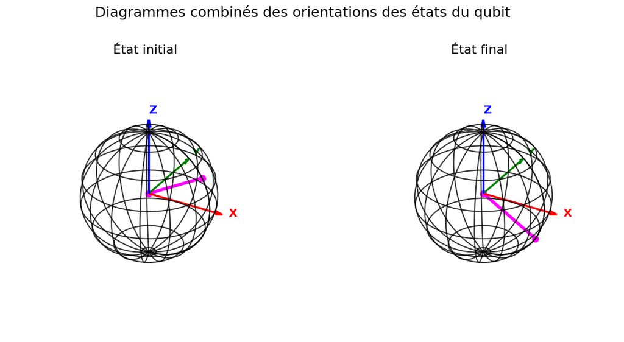

```python
from source.qubit_3D_simulation import *
from source.quantum_utils import *

# Construction d'un qubit de référence pour illustrer toutes les opérations

alpha = np.sqrt(3) / 2
beta = 1 / 2

qubit = np.array([alpha, beta])

# Observation initiale du qubit

print("\nÉtat du qubit avant le passage dans la porte X : ")
quantum.show(qubit)


# Utilisation de la porte sur le nouveau qubit

print("\nÉtat du qubit après le passage dans la porte X : ")

new_qubit = Pauli_X(qubit)

# Affichage du nouveau qubit avec construction du schéma

quantum.show(new_qubit)

plot_combined_snapshots(qubit, new_qubit,
                        "Diagrammes combinés des orientations des états du qubit")
```

### La porte Y

C'est une porte de rotation sur l'axe Y .

Nous la programmons de la manière suivante :

```python
# Définition de la fonction pour la porte Y

Y = np.array([[0, 1j], [-1j, 0]])

def Pauli_Y(qubit):
    # On effectue un produit scalaire des deux matrices
    return np.dot(Y, qubit)
```

Exemple d'exécution :

```
État du qubit avant le passage dans la porte X :
[0.8660254 0.5      ]
phi( 0.0 ), theta( 60.00000000000001 )
Probabilité d'avoir 0 :  74.99999999999999 %
Probabilité d'avoir 1 :  25.0 %

État du qubit après le passage dans la porte Y  :
[0.+0.5j       0.-0.8660254j]
phi( -90.0 ), theta( 180.0 )
Probabilité d'avoir 0 :  25.0 %
Probabilité d'avoir 1 :  74.99999999999999 %
```

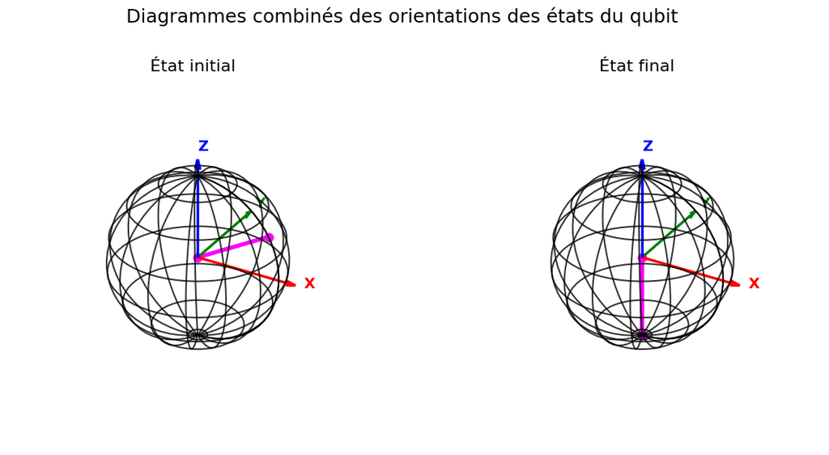

```python
print("\nÉtat du qubit avant le passage dans la porte X : ")
quantum.show(qubit)

new_qubit = Pauli_Y(qubit)

print("\nÉtat du qubit après le passage dans la porte Y  : ")
quantum.show(new_qubit)

plot_combined_snapshots(qubit, new_qubit,
                        "Diagrammes combinés des orientations des états du qubit")
```

### La porte Z

C'est une porte de rotation sur l'axe Z, elle applique une rotation de 180 degrés sur phi et laisse les probabilités d'obtenir 1 et 0 identiques à celles de l'état du qubit avant de traverser la porte.

La porte Z se définit mathématiquement de la manière suivante :

$$ Z = \begin{pmatrix} 1 & 0 \\ 0 & -1 \end{pmatrix} $$

Nous la programmons de la manière suivante :

```python
# Définition de la fonction pour la porte Z

Z = np.array([[1, 0], [0, -1]])

def Pauli_Z(qubit):
    # On effectue un produit scalaire des deux matrices
    return np.dot(Z, qubit)
```

Exemple d'éxecution :

```
État du qubit avant le passage dans la porte Z :
[0.8660254 0.5      ]
phi( 0.0 ), theta( 60.00000000000001 )
Probabilité d'avoir 0 :  74.99999999999999 %
Probabilité d'avoir 1 :  25.0 %

État du qubit après le passage dans la porte Z  :
[ 0.8660254 -0.5      ]
phi( 180.0 ), theta( 60.00000000000001 )
Probabilité d'avoir 0 :  74.99999999999999 %
Probabilité d'avoir 1 :  25.0 %
```

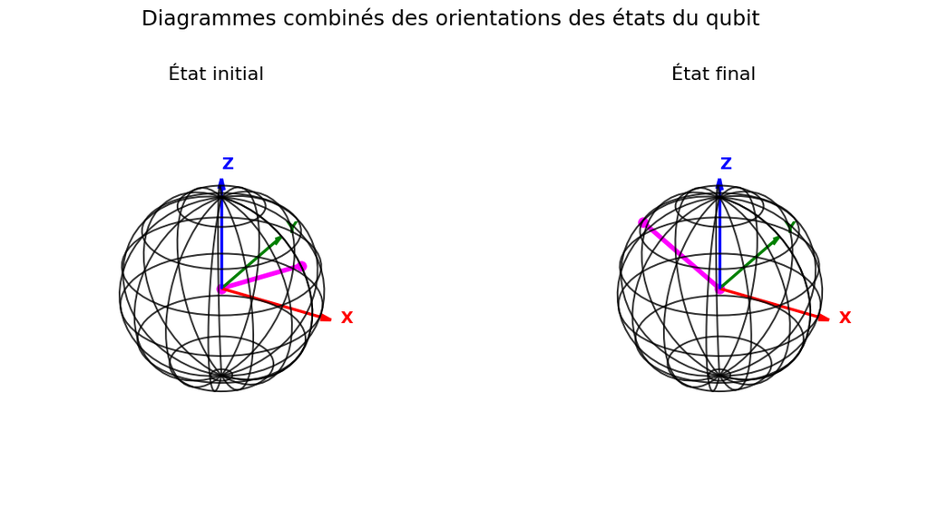

```python
print("\nÉtat du qubit avant le passage dans la porte Z : ")
quantum.show(qubit)

new_qubit = Pauli_Z(qubit)

print("\nÉtat du qubit après le passage dans la porte Z  : ")
quantum.show(new_qubit)


plot_combined_snapshots(qubit, new_qubit,
                        "Diagrammes combinés des orientations des états du qubit")
```

## La porte de Hadamard

En physique, la porte de Hadamard met un qubit en superposition avec de nouvelles valeurs. On entend par superposition le fait de pouvoir être simultanément 0 et 1 au même moment avant la mesure du qubit.

Mathématiquement, on structure la matrice de cette manière :

$$ H = \frac{1}{\sqrt{2}} \begin{pmatrix} 1 & 1 \\ 1 & -1 \end{pmatrix} $$

On la définit en python avec

```python
# Définition de la fonction pour la porte de Hadamard

def Hadamard(qubit):

    # Matrice de la porte de Hadamard
    matrice = (1 / np.sqrt(2)) * np.array([[1, 1], [1, -1]])

    # On effectue un produit scalaire des deux
    return np.dot(matrice, qubit)
```

Exemple d'éxecution :

```
État du qubit avant le passage dans la porte Hadamard :
[0.8660254 0.5      ]
phi( 0.0 ), theta( 60.00000000000001 )
Probabilité d'avoir 0 :  74.99999999999999 %
Probabilité d'avoir 1 :  25.0 %

État du qubit après le passage dans la porte Hadamard :
[0.96592583 0.25881905]
phi( 0.0 ), theta( 30.000000000000036 )
Probabilité d'avoir 0 :  93.30127018922192 %
Probabilité d'avoir 1 :  6.6987298107780635 %
```

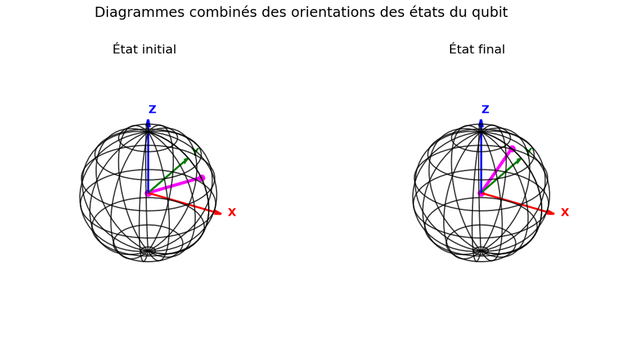

```python
print("\nÉtat du qubit avant le passage dans la porte Hadamard : ")
quantum.show(qubit)

new_qubit = Hadamard(qubit)

print("\nÉtat du qubit après le passage dans la porte Hadamard : ")
quantum.show(new_qubit)

plot_combined_snapshots(qubit, new_qubit,
                        "Diagrammes combinés des orientations des états du qubit")
```

## Les portes de déphasages

### La porte S

La porte S est aussi connue sous l'appellation de la porte de phase.

Elle se définit mathématiquement de la manière suivante :

$$ S = \begin{pmatrix} 1 & 0 \\ 0 & i \end{pmatrix} $$

On la définit en python avec

```python
# Définition de la fonction pour la porte de S

def S(qubit):

    # Matrice de la porte de S
    matrice = np.array([[1, 0], [0, 1j]])

    # On effectue un produit scalaire des deux
    return np.dot(matrice, qubit)
```

Exemple d'éxecution :

```
État du qubit avant le passage dans la porte S :
[0.8660254 0.5      ]
phi( 0.0 ), theta( 60.00000000000001 )
Probabilité d'avoir 0 :  74.99999999999999 %
Probabilité d'avoir 1 :  25.0 %

État du qubit après le passage dans la porte S :
[0.8660254+0.j  0.       +0.5j]
phi( 90.0 ), theta( 60.00000000000001 )
Probabilité d'avoir 0 :  74.99999999999999 %
Probabilité d'avoir 1 :  25.0 %
```

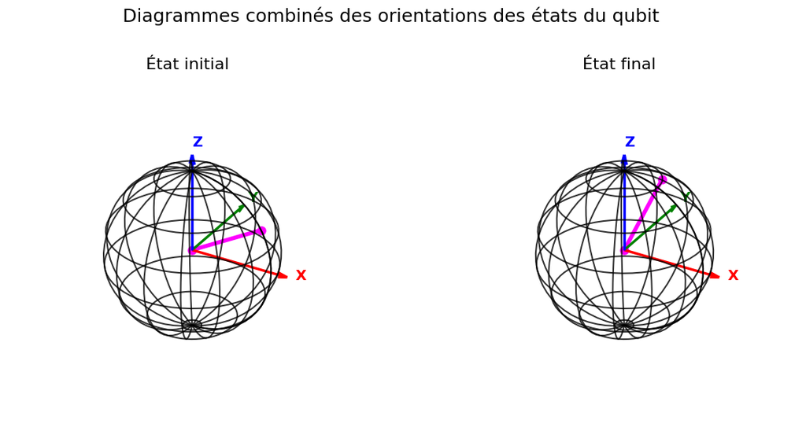

```python
print("\nÉtat du qubit avant le passage dans la porte S : ")
quantum.show(qubit)

new_qubit = S(qubit)

print("\nÉtat du qubit après le passage dans la porte S : ")
quantum.show(new_qubit)

plot_combined_snapshots(qubit, new_qubit,
                        "Diagrammes combinés des orientations des états du qubit")
```

### La porte T

La porte T est aussi connue sous l'appellation de la porte de phase $π/8$.

Elle se définit mathématiquement de la manière suivante :

$$ T = \begin{pmatrix} 1 & 0 \\ 0 & e^{i\pi/4} \end{pmatrix} $$

On la définit en python avec

```python
# Définition de la fonction pour la porte de T

def T(qubit):

    # Matrice de la porte de T
    matrice = np.array([[1, 0], [0, np.exp(1j * np.pi / 4)]])

    # On effectue un produit scalaire des deux
    return np.dot(matrice, qubit)
```

Exemple d'éxecution :

```
État du qubit avant le passage dans la porte T :
[0.8660254 0.5      ]
phi( 0.0 ), theta( 60.00000000000001 )
Probabilité d'avoir 0 :  74.99999999999999 %
Probabilité d'avoir 1 :  25.0 %

État du qubit après le passage dans la porte T :
[0.8660254 +0.j         0.35355339+0.35355339j]
phi( 45.0 ), theta( 60.00000000000001 )
Probabilité d'avoir 0 :  74.99999999999999 %
Probabilité d'avoir 1 :  25.0 %
```

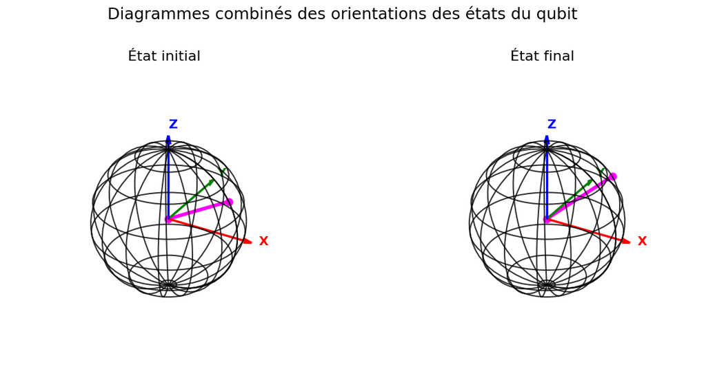

```python
print("\nÉtat du qubit avant le passage dans la porte T : ")
quantum.show(qubit)

new_qubit = T(qubit)

print("\nÉtat du qubit après le passage dans la porte T : ")
quantum.show(new_qubit)

plot_combined_snapshots(qubit, new_qubit,
                        "Diagrammes combinés des orientations des états du qubit")
```

## Les portes de rotations

### La porte RX

La porte RX est une porte de rotation d'angle θ dans le sens horaire sur l'axe X.

La porte RX est mathématiquement représentée comme cela :

$$ RX(\theta) = \begin{pmatrix} \cos(\theta/2) & -i\sin(\theta/2) \\ -i\sin(\theta/2) & \cos(\theta/2) \end{pmatrix} $$

On la définit en Python avec

```python
# Définition de la fonction pour la porte de RX

def RX(qubit, theta):

    # Matrice de la porte RX
    matrice = np.array([
        [np.cos(theta / 2), -1j * np.sin(theta / 2)],
        [-1j * np.sin(theta / 2), np.cos(theta / 2)]
    ])

    # On effectue un produit scalaire des deux
    return np.dot(matrice, qubit)
```

Exemple d'éxecution :

```
État du qubit avant le passage dans la porte RX :
[0.8660254 0.5      ]
phi( 0.0 ), theta( 60.00000000000001 )
Probabilité d'avoir 0 :  74.99999999999999 %
Probabilité d'avoir 1 :  25.0 %

État du qubit après le passage dans la porte RX :
[0.84938497-0.09754516j 0.49039264-0.16895317j]
phi( -19.01017801424429 ), theta( 66.50627713220759 )
Probabilité d'avoir 0 :  73.09698831278216 %
Probabilité d'avoir 1 :  26.90301168721783 %
```

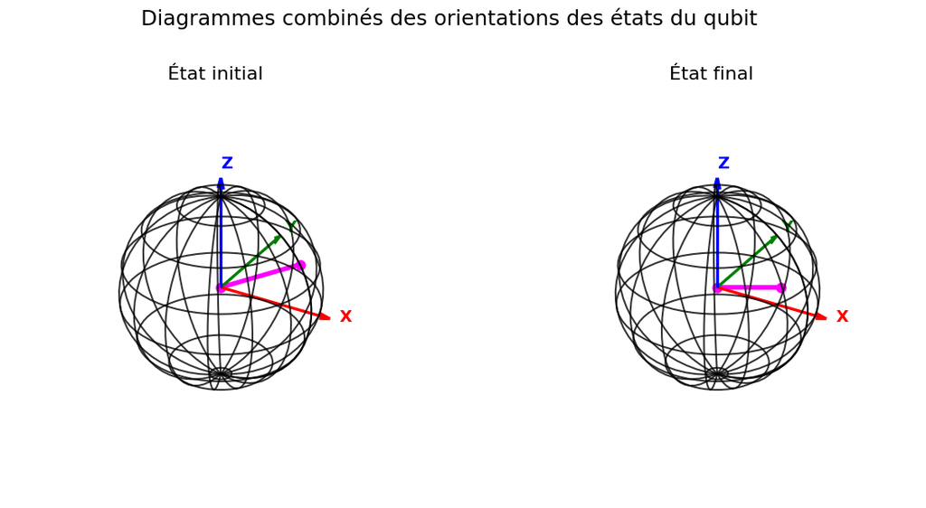

```python
print("\nÉtat du qubit avant le passage dans la porte RX : ")
quantum.show(qubit)

new_qubit = RX(qubit,np.pi/8)

print("\nÉtat du qubit après le passage dans la porte RX : ")
quantum.show(new_qubit)

plot_combined_snapshots(qubit, new_qubit,
                        "Diagrammes combinés des orientations des états du qubit")
```

### La porte RY

La porte RY est une porte de rotation d'angle θ dans le sens horaire sur l'axe Y.

La porte RY est mathématiquement représentée comme cela :

$$ RY(\theta) = \begin{pmatrix} \cos(\theta/2) & -\sin(\theta/2) \\ \sin(\theta/2) & \cos(\theta/2) \end{pmatrix} $$

On la définit en Python avec

```python
# Définition de la fonction pour la porte de RY

def RY(qubit, theta):

    # Matrice de la porte RY
    matrice = np.array([
        [np.cos(theta / 2), -np.sin(theta / 2)],
        [np.sin(theta / 2), np.cos(theta / 2)]
    ])

    # On effectue un produit matriciel des deux
    return np.dot(matrice, qubit)
```

Exemple d'éxecution :

```
État du qubit avant le passage dans la porte RY :
[0.8660254 0.5      ]
phi( 0.0 ), theta( 60.00000000000001 )
Probabilité d'avoir 0 :  74.99999999999999 %
Probabilité d'avoir 1 :  25.0 %

État du qubit après le passage dans la porte RY :
[0.75183981 0.65934582]
phi( 0.0 ), theta( 82.50000000000001 )
Probabilité d'avoir 0 :  56.52630961100258 %
Probabilité d'avoir 1 :  43.47369038899742 %
```

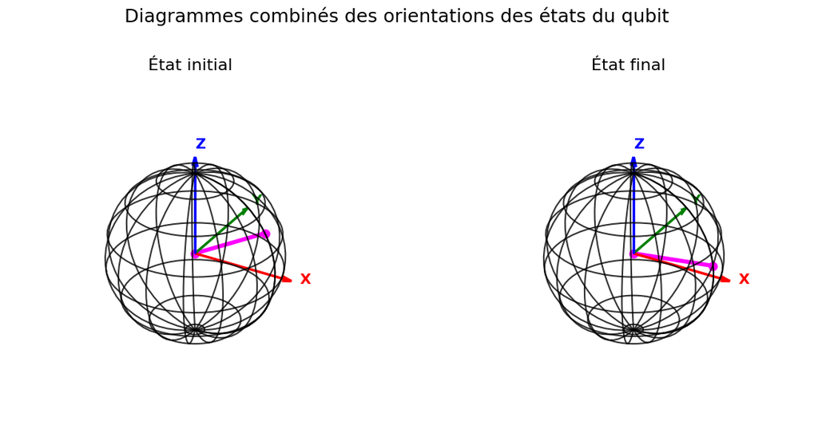

```python
print("\nÉtat du qubit avant le passage dans la porte RY : ")
quantum.show(qubit)

new_qubit = RY(qubit,np.pi/8)

print("\nÉtat du qubit après le passage dans la porte RY : ")
quantum.show(new_qubit)

plot_combined_snapshots(qubit, new_qubit,
                        "Diagrammes combinés des orientations des états du qubit")
```

### La porte RZ

La porte RZ est une porte de rotation d'angle θ dans le sens horaire sur l'axe Z.

La porte RZ est mathématiquement représentée ainsi :

$$ RZ(\theta) = \begin{pmatrix} e^{-i\theta/2} & 0 \\ 0 & e^{i\theta/2} \end{pmatrix} $$

On la définit en python avec

```python
# Définition de la fonction pour la porte de RZ

def RZ(qubit, theta):

    # Matrice de la porte RZ
    matrice = np.array([
        [np.exp(-1j * theta / 2), 0],
        [0, np.exp(1j * theta / 2)]
    ])

    # On effectue un produit matriciel des deux
    return np.dot(matrice, qubit)
```

Exemple d'éxecution :

```
État du qubit avant le passage dans la porte RZ :
[0.8660254 0.5      ]
phi( 0.0 ), theta( 60.00000000000001 )
Probabilité d'avoir 0 :  74.99999999999999 %
Probabilité d'avoir 1 :  25.0 %

État du qubit après le passage dans la porte RZ :
[0.84938497-0.16895317j 0.49039264+0.09754516j]
phi( 11.25 ), theta( 70.75149783092486 )
Probabilité d'avoir 0 :  74.99999999999999 %
Probabilité d'avoir 1 :  25.0 %
```

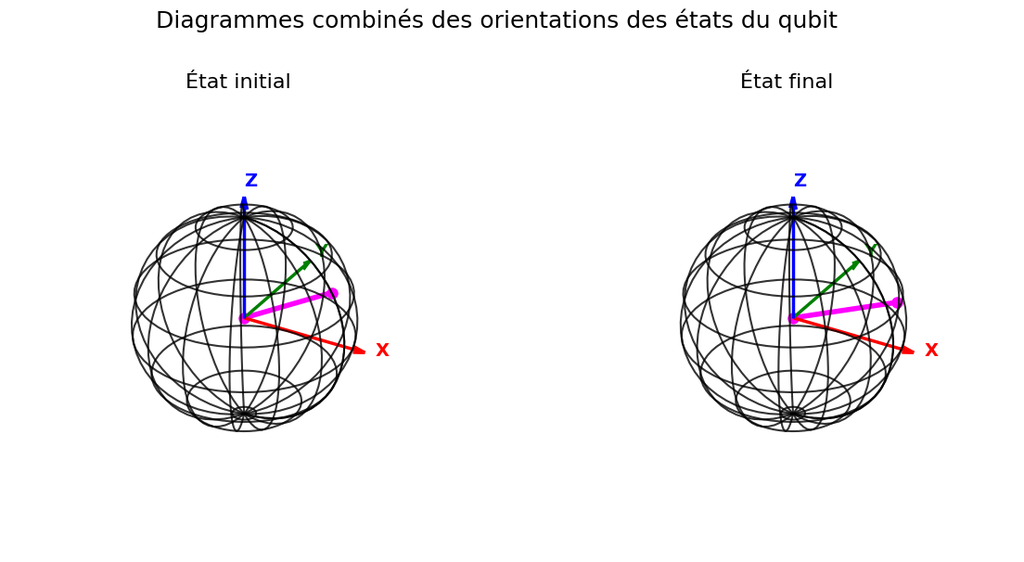

```python
print("\nÉtat du qubit avant le passage dans la porte RZ : ")
quantum.show(qubit)

new_qubit = RZ(qubit,np.pi/8)

print("\nÉtat du qubit après le passage dans la porte RZ : ")
quantum.show(new_qubit)

plot_combined_snapshots(qubit, new_qubit,
                        "Diagrammes combinés des orientations des états du qubit")
```